# Introduction to R

Jiantong Wang

5/4/2023

# Download and Installation

## R

- Download at https://cran.r-project.org/
- Windows user: click base then download the latest version for Windows. http://cran.r-project.org/bin/windows/base/
- Mac user (Intel): https://cran.r-project.org/bin/macosx/base/R-4.2.0.pkg
- Mac user (M1): https://cran.r-project.org/bin/macosx/big-sur-arm64/base/R-4.2.0-arm64.pkg

## R Studio

RStudio is an integrated development environment (IDE) for R. It includes a console, syntax-highlighting editor that supports direct code execution, as well as tools for plotting, history, debugging and workspace management.

It’s open-source software. (choose your OS version to download: https://www.rstudio.com/products/rstudio/download/)

When you open Rstudio, it looks like this:

[figure not shown]

Rstudio

If you would like to change background color to dark theme, you may configure by clicking (Tools > Global Options…> Appearance > Editor theme: Monaco)

[figure not shown]

Settings

[figure not shown]

Rstudio in Dark Mode

As you can see from the interface above, there are three panels showing. The left hand panel is called *console*, it is where you run any command and see the output. The upper right panel is where RStudio shows data you have loaded, variables that have been defined, and other objects. The lower right panel is where the Files/Plots/Packages…etc., can be found.

Generally, you may want to code in editor rather than in console directly. When you click the green plus icon in the top-left corner, and select R script, you will find left panel split into two parts and a new script editor window shows up.

Now it’s time to get your hands dirty following the instructions and practice on the fundamental R commands.

# Fundamental R Commands

## Before Coding

### -Set your working directory

- Always set the working directory before you begin coding.
- Working directory is the folder where you may load data, save output, and save the code.

```r
#You can use getwd() to check your current working directory.
getwd()
```

```
## [1] "/Users/woshiamie/Desktop/UC/Teaching/BANA4090_23Summer/Module 1"
```

You can set your working directory by using *setwd(“path”)* command or manually clicking *Session > Set Working Directory > Choose Directory…*, or use *Ctrl + Shift + H* and choose the folder that you want to set as working directory.

## -Using R as a Calculator

### Assign values to an object

Type the following code in the editor and run it line by line. To run a line of code, you can move the cursor to that line and use Ctrl + Enter (Cmd+Enter for Mac). If you want to run multiple lines of code, simply highlight those lines and use the same command.

“<-” and “=” are both assignment operator which assigns the right-hand side value to the left-hand side object.

```r
x <- 88
y = 0.8
x * y + x / y
```

```
## [1] 180.4
```

Try these additional functions:

```r
log(x); exp(x/y); sin(x); cos(y); sqrt(y)
```

### [Exercise]

*$E=mc^2$*, equation in German-born physicist Albert Einstein’s theory of Special relativity that expresses the fact that mass and energy are the same physical entity and can be changed into each other. How much energy can 1 kg matter (any matter) be turned into?

*$m = 1 kg$: mass of matter

- $c = 3 * 108 ms^{-1}$: speed of light
- $E = ?$

## -Logical Operaitons

Logical operaitons return TRUE (T) or FALSE (F)

```r
x == y
```

```
## [1] FALSE
```

```r
x > y
```

```
## [1] TRUE
```

```r
2 >= 2
```

```
## [1] TRUE
```

```r
2 > 2
```

```
## [1] FALSE
```

And: &  
Or: |  
All: all()  
Any: any()

```r
TRUE & TRUE
```

```
## [1] TRUE
```

```r
TRUE & FALSE
```

```
## [1] FALSE
```

```r
FALSE & FALSE
```

```
## [1] FALSE
```

```r
TRUE | TRUE
```

```
## [1] TRUE
```

```r
TRUE | FALSE
```

```
## [1] TRUE
```

```r
FALSE | FALSE
```

```
## [1] FALSE
```

```r
all(c(T,T,T,T,F))
```

```
## [1] FALSE
```

```r
all(c(T,T,T,T,T))
```

```
## [1] TRUE
```

```r
any(c(T,T,T,T,F))
```

```
## [1] TRUE
```

```r
any(c(F,F,F,F,F))
```

```
## [1] FALSE
```

## Install and Library packages

You can you install install.packages(“Package_name”) to install packages. After installation, you can use library() function to attach the package you want to use.

```r
install.packages("readxl")
```

## Data Structure

There are four types of data structures in R

- *Vector*
- *Matrix*
- *Data frame*
- *List*

### -Vector

A vector is the simplest type of data structure in R. Simply put, a vector is a sequence of data elements of the same basic type.

To assign a list of numbers (vector) to a variable, the numbers within the c command (combine) are separated by commas. For example, we can create a new variable called “p” which will contain the numbers 0.1, 0.3, 0.5 and 0.7:

```r
# Define numerical vector p
p <- c(0.1, 0.3, 0.5, 0.7)
# Define character vector pp
pp <- c("IBM", "Microsoft", "Apple", "AMD")
```

Note that you can put a # at the beginning of a line to write comments in your code.

#### - Calculations with a Numerical Vector

```r
# Average
mean(p)
```

```
## [1] 0.4
```

```r
# Standard deviation
sd(p)
```

```
## [1] 0.2581989
```

```r
# Median
median(p)
```

```
## [1] 0.4
```

```r
# Maximum
max(p)
```

```
## [1] 0.7
```

```r
# Minimum
min(p)
```

```
## [1] 0.1
```

```r
# Summary statistics
summary(p)
```

```
##    Min. 1st Qu.  Median    Mean 3rd Qu.    Max.
##    0.10    0.25    0.40    0.40    0.55    0.70
```

#### - Calculations for Multiple Vectors

```r
# Define vector p1
p1 <- c(1,3,5,7)
```

Elementwise operations (vectors must be the same length).

```r
p + p1
```

```
## [1] 1.1 3.3 5.5 7.7
```

```r
p * p1
```

```
## [1] 0.1 0.9 2.5 4.9
```

```r
p + 2
```

```
## [1] 2.1 2.3 2.5 2.7
```

```r
p / 10
```

```
## [1] 0.01 0.03 0.05 0.07
```

A vector of multiple vectors is still a vector.

```r
p2 <- c(p, p1)
p2
```

```
## [1] 0.1 0.3 0.5 0.7 1.0 3.0 5.0 7.0
```

#### - Indexing

To extract the second entry from vector p2:

```r
p2[2]
```

```
## [1] 0.3
```

To extract all elements greater than 5 from vector p2:

```r
p2[p2 > 5]
```

```
## [1] 7
```

To extract all elements greater than 5 and less than 7 from vector p2:

```r
p2[p2 > 5 & p2 < 7]
```

```
## numeric(0)
```

```r
# there's no such an element
```

To order the vector p2 from smallest to largest:

```r
p2[order(p2)]
```

```
## [1] 0.1 0.3 0.5 0.7 1.0 3.0 5.0 7.0
```

```r
sort(p2)
```

```
## [1] 0.1 0.3 0.5 0.7 1.0 3.0 5.0 7.0
```

```r
length(p)
```

```
## [1] 4
```

```r
# All but the first element in p
p[-1]
```

```
## [1] 0.3 0.5 0.7
```

### Matrix

Matrix is a collection of elements of the same data type (numeric, character, or logical) arranged into a fixed number of rows and columns.

Create a matrix using the matrix() function. This function creates a matrix from a given vector.

```r
#Define a matrix A
X <- matrix(data = p2, nrow = 2, ncol = 4)
X
```

```
##      [,1] [,2] [,3] [,4]
## [1,]  0.1  0.5    1    5
## [2,]  0.3  0.7    3    7
```

```r
class(X)
```

```
## [1] "matrix" "array"
```

In R functions, you may ignore the argument names and simply list the inputs in the correct order.

```r
X <- matrix(p2, 2, 4)
```

The default order to position the values of a vector in a matrix is by column, but you can specify it as by row using an additional argument byrow=T.

```r
X <- matrix(data = p2, nrow = 2, ncol = 4, byrow = T )
```

*Create a matrix using cbind() and rbind() functions*

cbind() is a function that combines vectors or matrices to a matrix by column.

```r
X <- cbind(p, p1)
X
```

```
##        p p1
## [1,] 0.1  1
## [2,] 0.3  3
## [3,] 0.5  5
## [4,] 0.7  7
```

```r
X <- rbind(p, p1)
```

#### - Matrix calculation

*Dimensions*

```r
dim(X)
```

```
## [1] 2 4
```

*Elementwise operations for matrices*

```r
X + 1
```

```
##    [,1] [,2] [,3] [,4]
## p   1.1  1.3  1.5  1.7
## p1  2.0  4.0  6.0  8.0
```

```r
X * 2
```

```
##    [,1] [,2] [,3] [,4]
## p   0.2  0.6    1  1.4
## p1  2.0  6.0   10 14.0
```

*Subsetting, indexing*

```r
# The element at the intersection of the second row and the second column
X[2,2]
```

```
## p1
##  3
```

```r
# The first row of matrix X
X[1, ]
```

```
## [1] 0.1 0.3 0.5 0.7
```

```r
X[, 2:3]
```

```
##    [,1] [,2]
## p   0.3  0.5
## p1  3.0  5.0
```

```r
X[1, c(1,3)]
```

```
## [1] 0.1 0.5
```

*Transpose and Multiplication*

```r
# Transpose
t(X)
```

```
##        p p1
## [1,] 0.1  1
## [2,] 0.3  3
## [3,] 0.5  5
## [4,] 0.7  7
```

```r
# Matrix multiplication
t(X) %*% X
```

```
##      [,1]  [,2]  [,3]  [,4]
## [1,] 1.01  3.03  5.05  7.07
## [2,] 3.03  9.09 15.15 21.21
## [3,] 5.05 15.15 25.25 35.35
## [4,] 7.07 21.21 35.35 49.49
```

## Data Frame

A data frame is a table where each row represents an observation and each column represents a variable. A data frame has column names (variable names) and row names.

### - Convert a Matrix to a Data Frame

The function data.frame(X) converts the matrix X into a data frame.

```r
df <- data.frame(X)
class(df)
```

```
## [1] "data.frame"
```

```r
df
```

```
##     X1  X2  X3  X4
## p  0.1 0.3 0.5 0.7
## p1 1.0 3.0 5.0 7.0
```

### - Read External Data Files (.txt and .csv files)

Use read.table() or read.csv() functions to import comma/space/tab delimited text files. You can also use the Import Dataset Wizard in RStudio (File > Import Dataset…). The package “readxl” allows you to read xls/xlsx files as well.

First, download the Dulles_2.csv file from Canvas and save it in your working directory.

```r
mydata_csv <- read.csv("Dulles_2.csv", header = T)
```

## List

A list is a container. You can put different types of objects into a list.

```r
mylist <- list(myvector = p, mymatrix = X, mydata = mydata_csv)
mylist
```

```
## $myvector
## [1] 0.1 0.3 0.5 0.7
##
## $mymatrix
##    [,1] [,2] [,3] [,4]
## p   0.1  0.3  0.5  0.7
## p1  1.0  3.0  5.0  7.0
##
## $mydata
##    Year Passengers..000s.
## 1  1963               641
## 2  1964               728
## 3  1965               920
## 4  1966              1079
## 5  1967              1427
```

[output cut: 48 more lines]

## Time Series Plotting

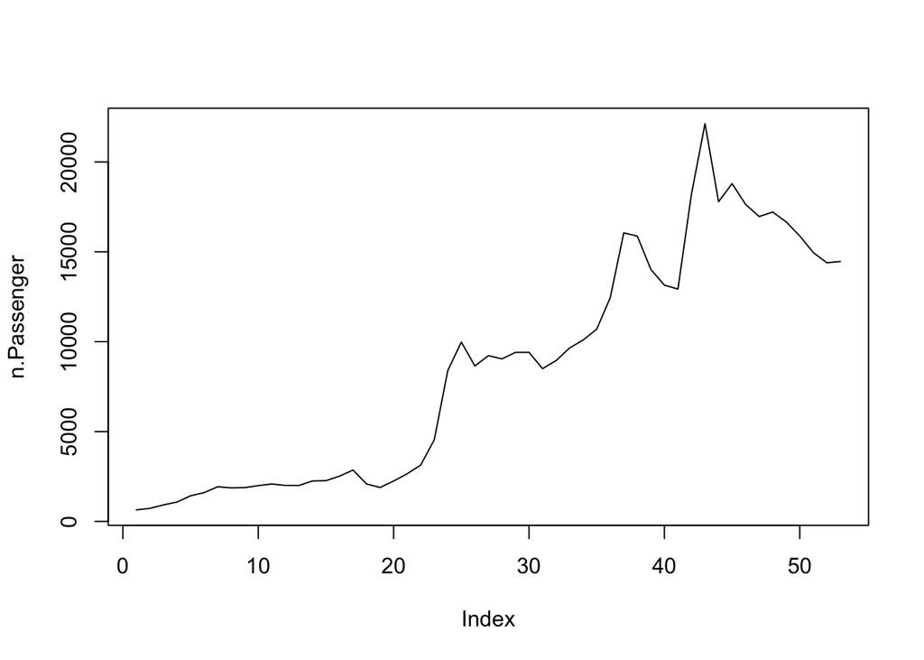

```r
#Store the data in a conveniently named variable
n.Passenger <- mydata_csv$Passengers..000s.
#Create line chart
plot(n.Passenger, type = "l")
```

```r
#Change to Time-Series Object
#install.packages("zoo")
library(zoo)
Dulles <- ts(mydata_csv$Passengers..000s.,start = 1963, freq = 1)
head(Dulles)
```

```
## [1]  641  728  920 1079 1427 1602
```

```r
#install.packages("forecast")
require("forecast")
```

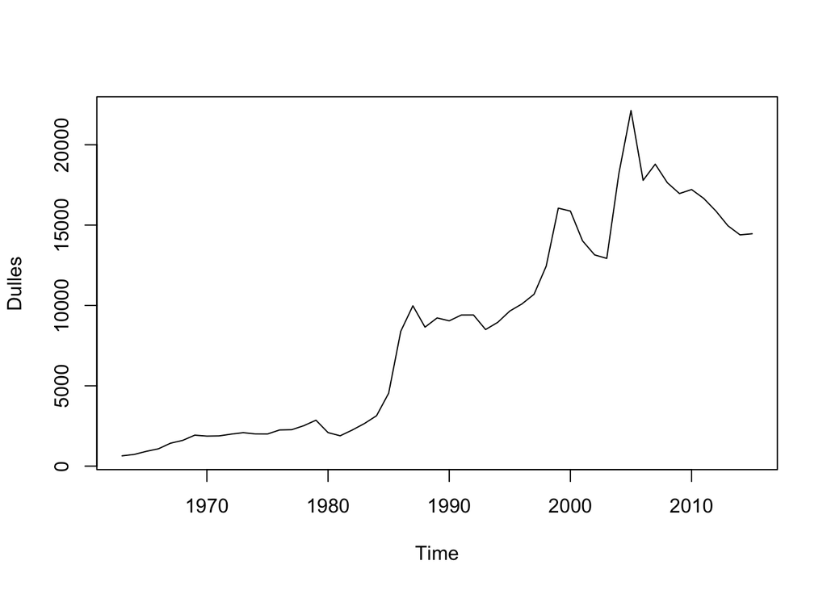

```r
plot(Dulles)
```